# Frequent Pattern Analysis/Association Rules Mining

Xuan Pham

2018-11-27

# R Packages

The packages you will need to install for the week are **Matrix**, **arules** and **arulesViz**.

```r
library(Matrix)
library(arules)
```

```r
library(arulesViz)
```

# Strawberry Pop-tarts During Hurricanes

What do you think people buy to “stock up” before a hurricane? We would expect that people buy sandbags, flashlights, and other similar items to prepare for hurricanes. Walmart figured out that people buy strawberry pop-tarts too! Here is the original [story](http://www.nytimes.com/2004/11/14/business/yourmoney/what-walmart-knows-about-customers-habits.html).

Our task for this week is in the similar vein. We will be looking at datasets to see if we can find regularities in them.

# Frequent Pattern Analysis (Association Rules Mining)

We have examined several unsupervised learning models: k-means, k-modes, k-prototype, hierarchical clustering, and principal components analysis. We will examine another unsupervised learning method this week called **frequent pattern analysis (FPA)**.

Applications of FPA include analyses of market basket, DNA sequence, click stream analysis, and marketing activities (sale campaign; cross-marketing; etc.). We are going to examine two FPA algorithms: **Apriori** and **ECLAT**. **Apriori** is the more popular algorithm, but it can take up a lot of computational resources. **ECLAT** is a more efficient algorithm (i.e. faster) on smaller datasets.

# Data Mining Goal

What interesting rules can we discover from 9,835 transactions containing 169 grocery products? In particular, if a customer purchases a particular grocery item (such as milk), what other grocery items would the customer likely to purchase as well? (i.e. bread, flowers, cheese, etc.)

# The Dataset

The *Groceries* dataset contains 9,835 transactions of 169 aggregated categories at a grocery store. The data was collected over a one month period.

Source of dataset:

Michael Hahsler, Kurt Hornik, and Thomas Reutterer (2006) Implications of probabilistic data modeling for mining association rules. In M. Spiliopoulou, R. Kruse, C. Borgelt, A. Nuernberger, and W. Gaul, editors, From Data and Information Analysis to Knowledge Engineering, Studies in Classification, Data Analysis, and Knowledge Organization, pages 598-605. Springer-Verlag.

# Basic Concepts

Assume we have the following transaction database.

| ID | Items |
| --- | --- |
| 10 | Beer, Nuts, Diapers |
| 20 | Beer, Coffee, Diapers |
| 30 | Beer, Diapers, Eggs |
| 40 | Nuts, Eggs, Milk |
| 50 | Nuts, Coffee, Diapers, Eggs, Milk |

An **itemset** is a list containing one or more items from the dataset.

Here are all the possible 1-itemset from the database above:

1-itemset: {beer},{nuts},{diaper},{coffee},{eggs},{milk}

Here are all the possible 2-itemsets from the database above:

2-itemset: {beer, nuts}; {beer, diaper}; {beer, coffee}; {beer, eggs}; {beer, milk}; {nuts, diaper}; {nuts, coffee}; {nuts, eggs}; {nuts, milk}; {diaper, coffee}; {diapers, eggs}; {diapers, milk}; {coffee, eggs}; {coffee, milk}; {eggs, milk}

3-itemset and 4-itemset are created in similar fashions.

**Absolute Support** is the count of occurrences of itemset X. For example, the absolute support for the 2-itemset {beer, diaper} is 3. The absolute support for the 2-itemset {eggs, milk} is 2.

**Relative Support** is the fraction of transactions that contain itemset X. For example, the relative support for the 2-itemset {beer, diaper} is 0.6

$Relative.Support = \frac{Count(X)}{n}=\frac{3}{5}=0.6$

If we try to generate all possible combinations of items, the computational time would grow exponentially. As a result, we impose a condition that we would only examine item combinations that occur with higher frequency in the database. An itemset is said to be **frequent** if its support >= minimum support threshold (minsup). The minsup value is set by the user and should reflect business knowledge. For example, we may set a minimum support threshold of 0.05 (or 5%). We would only consider itemsets that occurred in 5% of the database.

FPA results in a set of association rules. A typical association rule would state that given itemset X, then itemset Y is likely to occur. For example, {diaper} -> {beer}. Customers who purchase diapers are likely to purchase beer. Diaper is called the **antecedent**, and beer is called the **consequent** in this association rule. In other words, if we can compare an association rule to an IF-THEN statement, the IF is the antecedent and THEN is the consequent.

Association rules are determined based on several quality measures:

## 1. Support

**Support**: How often does the rule happen in the database? In other words, the support of a rule is the **number of transactions that include both the antecedent and consequent itemsets**. Absolute support is the actual count of the rule as observed in the database. Relative support is the fraction (or percent) of the rule as observed in the database.

## 2. Confidence

**Confidence**: How often is the rule correct?

$Confidence=\frac {support(X,Y)}{support(X)}$

Confidence is the **ratio of the number of transactions with both antecedent and consequent itemsets and the number of transactions with antecedent itemset**.

The user sets the **minimum support (minsup)** and **minimum confidence (minconf)** thresholds. **Rule interestingness** is determined by the minsup and minconf. Applied algorithms only report association rules that meet or exceed the minsup and minconf thresholds.

For example, let’s say we set the minsup = 50% and minconf=50%

Here are two association rules that are “interesting.”

```
{diaper}->{beer}

support(diaper,beer)=(count(diaper,beer))/N=3/5=0.6

confidence(diaper,beer)=(support(diaper,beer))/(support(diaper))=3/4=0.75

We report this rule as follows: diapers->beer (60%, 75%)
```

```
{beer}->{diaper}

support(beer,diaper)=(count(beer,diaper))/N=3/5=0.6

confidence(beer,diaper)=support(beer,diaper)/support(beer) =3/3=1.0

We report this rule as follows: beer -> diapers (60%, 100%)
```

Once we have identified the interesting rules, we want to be able to filter down to the strong rules. Strong rules are the ones that have high confidence. The problem with using “high confidence” as a benchmark is that we can get a high value for confidence even when the antecedent and consequent are independent. As long as there is a high level of support for the antecedent and consequent itemsets (separately), we would get a high confidence.

## 3. Lift Ratio

**Lift Ratio**: The lift ratio measures the strength of a rule against random chance. The lift ratio overcomes the problem of getting a high confidence value even when the antecedent and consequent itemsets are independent. **We start by assuming that there is no association (i.e. complete independence) between the antecedent and consequent itemsets in a given rule.** We calculate the support for the antecedent itemsets and support for the consequent itemsets separately. We then use the calculated supports to derive a benchmark confidence.

$Benchmark.Confidence(X->Y)=\frac{support(X)*support(Y)}{support(X)}=support(Y)$

The benchmark confidence, thus, is nothing more than the support for the consequent itemset. We can expressed the benchmark confidence ratio in terms of relative support for the consequent itemset. n (in the equation below) refers to the number of transactions in a database.

$Benchmark.Confidencce(X->Y)=\frac{support(Y)}{n}$

The lift ratio is then calculated as the ratio of confidence to the benchmark confidence.

$Lift.Ratio=\frac{Confidence(X->Y)}{Benchmark.Confidence(X->Y)}$

A lift ratio greater than 1 suggests that the level of association between the antecedent and consequent itemsets is higher than would be expected if they were independent from each other. The larger the lift ratio, the greater the strength of the association.

For example:

```
Confidence(diaper --> beer) = 0.75

Support(beer) = 0.6

Lift = 0.75/0.6 = 1.25
```

# How Do FPA Algorithms Work?

FPA algorithms utilize a search tree to generate frequent itemsets. A search tree starts with an empty itemset in its initialization. Using the minsup threshold established by the user, a set of candidate itemsets are generated. Support for each candidate itemset is then generated. If a search tree tries to generate all possible candidate itemsets, the process would be very computationally intensive for large datasets. As a result, most FPA algorithms utilize the **downward closure property**. Downward closure states that a supersede itemset cannot be frequent if its subset itemsets are not frequent. Consequently, most FPA algorithms will only generate candidates and count support for those itemsets that meet the downward closure property.

Below is an illustration of the search tree that applies the downward closure property. We assume here that the minsup = 50%. Notice that no 3-itemset candidates are generated because only one 2-itemset {beer, diapers} is frequent.

[search_tree_image](https://sites.google.com/site/xuanphamru/images/searchtree.jpg)

# Getting Started

The original data frame has 9,835 transactions with 169 grocery products. This translates into a sparse matrix with 9,835 rows and 169 columns.

```r
library(Matrix)
library(arules)
groceries <- read.transactions("C:/Users/PhamX/Dropbox/Fall_2018/BIA_6301/Week_6/groceries.csv", sep = ",") #9,835 transactions with 169 products.
```

Let’s visualize the sparse matrix. You cannot make much sense of this picture.

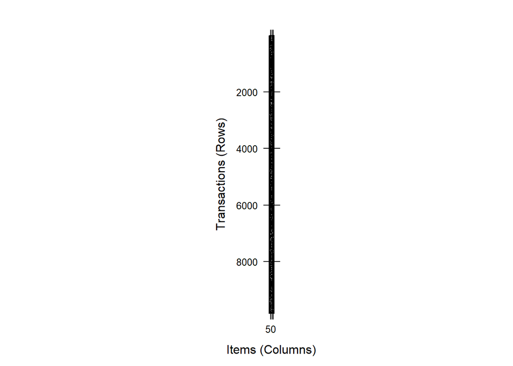

```r
image(groceries)
```

Let’s narrow it down to the first five transactions.

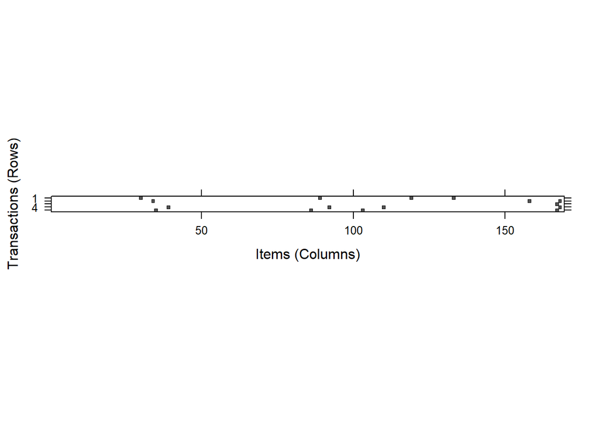

```r
image(groceries[1:5])
```

Another visualization. This time of a random sample of 100 transactions.

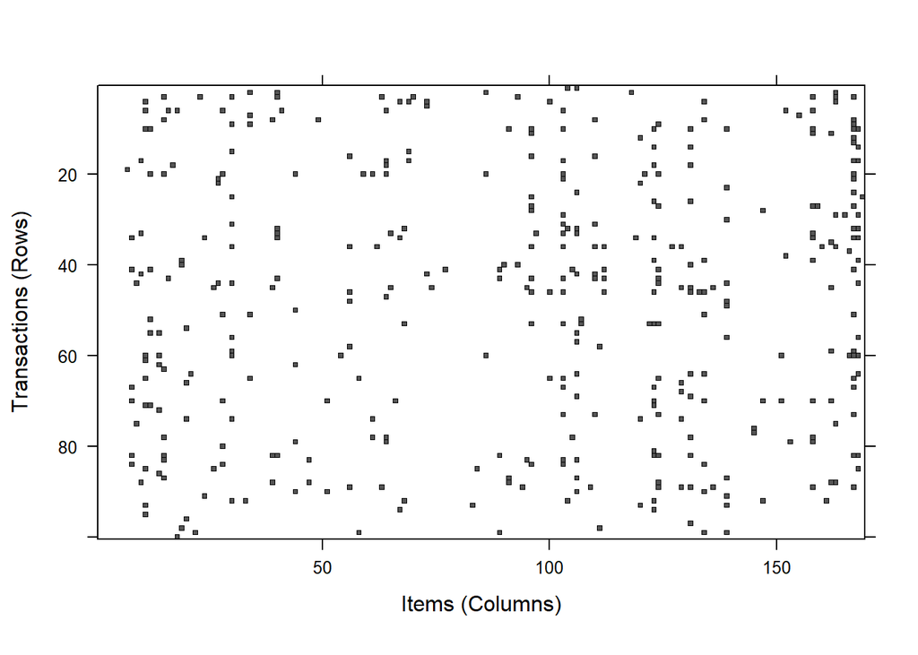

```r
image(sample(groceries, 100))
```

Can we quickly summarize the sparse matrix? Yes!

```r
summary(groceries)
```

```
## transactions as itemMatrix in sparse format with
##  9835 rows (elements/itemsets/transactions) and
##  169 columns (items) and a density of 0.02609146
##
## most frequent items:
##       whole milk other vegetables       rolls/buns             soda
##             2513             1903             1809             1715
##           yogurt          (Other)
##             1372            34055
##
## element (itemset/transaction) length distribution:
## sizes
##    1    2    3    4    5    6    7    8    9   10   11   12   13   14   15
## 2159 1643 1299 1005  855  645  545  438  350  246  182  117   78   77   55
##   16   17   18   19   20   21   22   23   24   26   27   28   29   32
##   46   29   14   14    9   11    4    6    1    1    1    1    3    1
##
##    Min. 1st Qu.  Median    Mean 3rd Qu.    Max.
##   1.000   2.000   3.000   4.409   6.000  32.000
##
## includes extended item information - examples:
##             labels
## 1 abrasive cleaner
## 2 artif. sweetener
## 3   baby cosmetics
```

Density indicates that only 2% of the elements are non-zero.

Mean is the average items per transaction.

Sum of “most frequent items” = total number of items bought in grocery dataset

Element is the frequency of a given number of items (i.e. 1, 2, 3, 4, etc.) bought in the transactions.

Here is another useful function that allows you to examine individual transactions.

```r
inspect(groceries[1:5])
```

```
##     items
## [1] {citrus fruit,
##      margarine,
##      ready soups,
##      semi-finished bread}
## [2] {coffee,
##      tropical fruit,
##      yogurt}
## [3] {whole milk}
## [4] {cream cheese,
##      meat spreads,
##      pip fruit,
##      yogurt}
## [5] {condensed milk,
##      long life bakery product,
##      other vegetables,
##      whole milk}
```

# Examining 1-itemset

Let’s count the **support** (or frequency) of the grocery items. We will put the support in a data frame so we can view them.

```r
itemFrequency(groceries)
```

```
##          abrasive cleaner          artif. sweetener
##              0.0035587189              0.0032536858
##            baby cosmetics                 baby food
##              0.0006100661              0.0001016777
##                      bags             baking powder
##              0.0004067107              0.0176919166
##          bathroom cleaner                      beef
##              0.0027452974              0.0524656838
##                   berries                 beverages
##              0.0332486019              0.0260294865
##              bottled beer             bottled water
##              0.0805287239              0.1105236401
##                    brandy               brown bread
##              0.0041687850              0.0648703610
##                    butter               butter milk
##              0.0554143366              0.0279613625
##                  cake bar                   candles
##              0.0132180986              0.0089476360
##                     candy               canned beer
##              0.0298932384              0.0776817489
##               canned fish              canned fruit
##              0.0150482969              0.0032536858
##         canned vegetables                  cat food
##              0.0107778343              0.0232841891
##                   cereals               chewing gum
##              0.0056939502              0.0210472801
##                   chicken                 chocolate
##              0.0429079817              0.0496187087
##     chocolate marshmallow              citrus fruit
##              0.0090493137              0.0827656329
##                   cleaner           cling film/bags
##              0.0050838841              0.0113879004
##              cocoa drinks                    coffee
##              0.0022369090              0.0580579563
##            condensed milk         cooking chocolate
##              0.0102694459              0.0025419420
##                  cookware                     cream
##              0.0027452974              0.0013218099
##              cream cheese                      curd
##              0.0396542959              0.0532791052
```

[output cut: 115 more lines]

```
##              0.0038637519              0.0023385867
##            toilet cleaner            tropical fruit
##              0.0007117438              0.1049313676
##                    turkey                  UHT-milk
##              0.0081342145              0.0334519573
##                   vinegar                   waffles
##              0.0065073716              0.0384341637
##        whipped/sour cream                    whisky
##              0.0716827656              0.0008134215
##               white bread                white wine
##              0.0420945602              0.0190137265
##                whole milk                    yogurt
##              0.2555160142              0.1395017794
##                  zwieback
##              0.0069140824
```

```r
freq_groceries_data_frame <- as.data.frame(itemFrequency(groceries))
head(freq_groceries_data_frame)
```

```
##                  itemFrequency(groceries)
## abrasive cleaner             0.0035587189
## artif. sweetener             0.0032536858
## baby cosmetics               0.0006100661
## baby food                    0.0001016777
## bags                         0.0004067107
## baking powder                0.0176919166
```

```r
tail(freq_groceries_data_frame)
```

```
##             itemFrequency(groceries)
## whisky                  0.0008134215
## white bread             0.0420945602
## white wine              0.0190137265
## whole milk              0.2555160142
## yogurt                  0.1395017794
## zwieback                0.0069140824
```

```r
#View(freq_groceries_data_frame)
```

Let’s pare this list down a bit to look at the first 15 items.

```r
itemFrequency(groceries[, 1:15])
```

```
## abrasive cleaner artif. sweetener   baby cosmetics        baby food
##     0.0035587189     0.0032536858     0.0006100661     0.0001016777
##             bags    baking powder bathroom cleaner             beef
##     0.0004067107     0.0176919166     0.0027452974     0.0524656838
##          berries        beverages     bottled beer    bottled water
##     0.0332486019     0.0260294865     0.0805287239     0.1105236401
##           brandy      brown bread           butter
##     0.0041687850     0.0648703610     0.0554143366
```

Plotting the support.

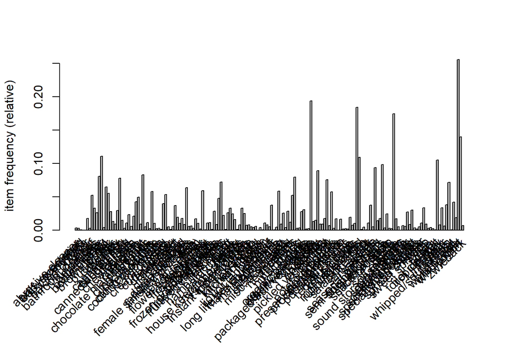

```r
itemFrequencyPlot(groceries)
```

Too much information! Let’s impose a rule. Minsup = 10%

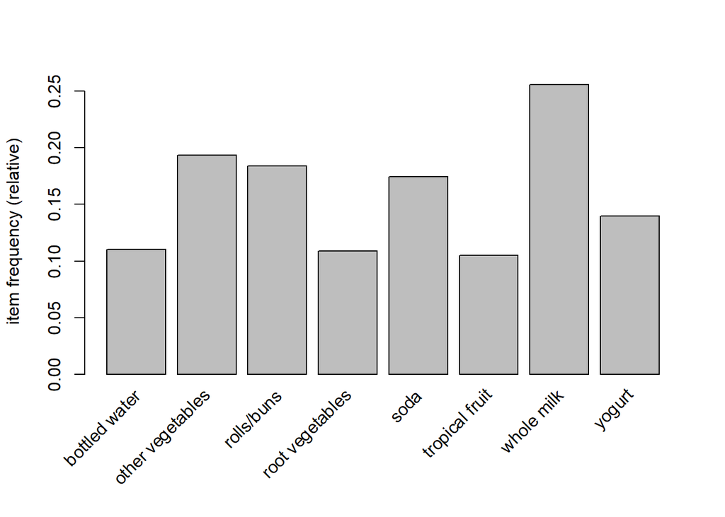

```r
itemFrequencyPlot(groceries, support = 0.1)
```

Here is a different take. Let’s say we want to look at the “top 20” items.

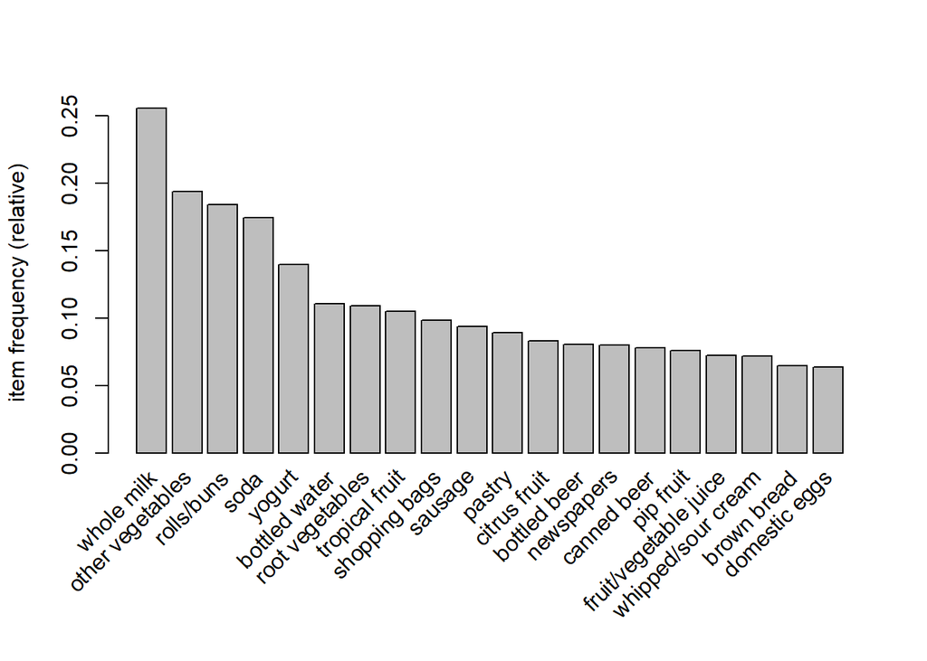

```r
itemFrequencyPlot(groceries, topN = 20)
```

# Apriori Algorithm

The most frequently used FPA algorithm is Apriori.

Pro: scalable for large datasets.

Con: computationally intensive. We have to keep comparing the candidate itemsets against the database until no frequent and/or candidate itemsets can be generated.

**Data format requirement**: Horizontal. One column has the tid-set number (tid= transaction ID). Another column has a list of items.

**Method**

1. Initialize by scanning the database once to get frequent 1-itemset
2. Generate length (k+1) candidate itemsets from length k frequent itemsets
3. Test the candidate itemsets against the database. Prune candidate itemsets based on the minimum support threshold (minsup).
4. Terminate when no frequent or candidate set can be generated.

## Exploring apriori() in arules Package

```r
#?apriori
```

### Default parameter settings

support = 0.1 (or 10%) confidence = 0.8 (or 80%) maxlen = maximum number of items in a rule. Default is 10. minlen = minimum number of items in a rule. Default is 1.

Let’s try the default parameter settings first.

```r
apriori(groceries)
```

```
## Apriori
##
## Parameter specification:
##  confidence minval smax arem  aval originalSupport maxtime support minlen
##         0.8    0.1    1 none FALSE            TRUE       5     0.1      1
##  maxlen target   ext
##      10  rules FALSE
##
## Algorithmic control:
##  filter tree heap memopt load sort verbose
##     0.1 TRUE TRUE  FALSE TRUE    2    TRUE
##
## Absolute minimum support count: 983
##
## set item appearances ...[0 item(s)] done [0.00s].
## set transactions ...[169 item(s), 9835 transaction(s)] done [0.01s].
## sorting and recoding items ... [8 item(s)] done [0.00s].
## creating transaction tree ... done [0.00s].
## checking subsets of size 1 2 done [0.00s].
## writing ... [0 rule(s)] done [0.00s].
## creating S4 object  ... done [0.00s].
```

```
## set of 0 rules
```

Not a single rule found! Let’s try again with some tweakings to the parameter settings.

```r
groceryrules <- apriori(groceries, parameter = list(support =
                          0.001, confidence = 0.8, minlen = 2))
```

```
## Apriori
##
## Parameter specification:
##  confidence minval smax arem  aval originalSupport maxtime support minlen
##         0.8    0.1    1 none FALSE            TRUE       5   0.001      2
##  maxlen target   ext
##      10  rules FALSE
##
## Algorithmic control:
##  filter tree heap memopt load sort verbose
##     0.1 TRUE TRUE  FALSE TRUE    2    TRUE
##
## Absolute minimum support count: 9
##
## set item appearances ...[0 item(s)] done [0.00s].
## set transactions ...[169 item(s), 9835 transaction(s)] done [0.01s].
## sorting and recoding items ... [157 item(s)] done [0.00s].
## creating transaction tree ... done [0.00s].
## checking subsets of size 1 2 3 4 5 6 done [0.02s].
## writing ... [410 rule(s)] done [0.00s].
## creating S4 object  ... done [0.00s].
```

Let’s count the number of rules found

```r
print(groceryrules)
```

```
## set of 410 rules
```

## Evaluating Performance

Let’s look at the number of rules and number of items per rule.

```r
summary(groceryrules)
```

```
## set of 410 rules
##
## rule length distribution (lhs + rhs):sizes
##   3   4   5   6
##  29 229 140  12
##
##    Min. 1st Qu.  Median    Mean 3rd Qu.    Max.
##   3.000   4.000   4.000   4.329   5.000   6.000
##
## summary of quality measures:
##     support           confidence          lift            count
##  Min.   :0.001017   Min.   :0.8000   Min.   : 3.131   Min.   :10.00
##  1st Qu.:0.001017   1st Qu.:0.8333   1st Qu.: 3.312   1st Qu.:10.00
##  Median :0.001220   Median :0.8462   Median : 3.588   Median :12.00
##  Mean   :0.001247   Mean   :0.8663   Mean   : 3.951   Mean   :12.27
##  3rd Qu.:0.001322   3rd Qu.:0.9091   3rd Qu.: 4.341   3rd Qu.:13.00
##  Max.   :0.003152   Max.   :1.0000   Max.   :11.235   Max.   :31.00
##
## mining info:
##       data ntransactions support confidence
##  groceries          9835   0.001        0.8
```

Let’s see what we found:

3-itemset: 29 rules

4-itemset: 229 rules

5-itemset: 140 rules

6-itemset: 12 rules

Total = 410 rules. Whew!

Let’s look at the first 10 rules. Please note the rules are not sorted in any order.

```r
inspect(groceryrules[1:10])
```

```
##      lhs                         rhs                    support confidence      lift count
## [1]  {liquor,
##       red/blush wine}         => {bottled beer}     0.001931876  0.9047619 11.235269    19
## [2]  {cereals,
##       curd}                   => {whole milk}       0.001016777  0.9090909  3.557863    10
## [3]  {cereals,
##       yogurt}                 => {whole milk}       0.001728521  0.8095238  3.168192    17
## [4]  {butter,
##       jam}                    => {whole milk}       0.001016777  0.8333333  3.261374    10
## [5]  {bottled beer,
##       soups}                  => {whole milk}       0.001118454  0.9166667  3.587512    11
## [6]  {house keeping products,
##       napkins}                => {whole milk}       0.001321810  0.8125000  3.179840    13
## [7]  {house keeping products,
##       whipped/sour cream}     => {whole milk}       0.001220132  0.9230769  3.612599    12
## [8]  {pastry,
##       sweet spreads}          => {whole milk}       0.001016777  0.9090909  3.557863    10
## [9]  {curd,
##       turkey}                 => {other vegetables} 0.001220132  0.8000000  4.134524    12
## [10] {rice,
##       sugar}                  => {whole milk}       0.001220132  1.0000000  3.913649    12
```

## Improving Performance

Let’s sort the rules by lift.

```r
groceryrules_sorted <- sort(groceryrules, by = "lift")
inspect(groceryrules_sorted[1:10])
```

```
##      lhs                        rhs                   support confidence      lift count
## [1]  {liquor,
##       red/blush wine}        => {bottled beer}    0.001931876  0.9047619 11.235269    19
## [2]  {citrus fruit,
##       fruit/vegetable juice,
##       other vegetables,
##       soda}                  => {root vegetables} 0.001016777  0.9090909  8.340400    10
## [3]  {oil,
##       other vegetables,
##       tropical fruit,
##       whole milk,
##       yogurt}                => {root vegetables} 0.001016777  0.9090909  8.340400    10
## [4]  {citrus fruit,
##       fruit/vegetable juice,
##       grapes}                => {tropical fruit}  0.001118454  0.8461538  8.063879    11
## [5]  {other vegetables,
##       rice,
##       whole milk,
##       yogurt}                => {root vegetables} 0.001321810  0.8666667  7.951182    13
## [6]  {oil,
##       other vegetables,
##       tropical fruit,
##       whole milk}            => {root vegetables} 0.001321810  0.8666667  7.951182    13
## [7]  {ham,
##       other vegetables,
##       pip fruit,
##       yogurt}                => {tropical fruit}  0.001016777  0.8333333  7.941699    10
## [8]  {beef,
##       citrus fruit,
##       other vegetables,
##       tropical fruit}        => {root vegetables} 0.001016777  0.8333333  7.645367    10
## [9]  {butter,
##       cream cheese,
##       root vegetables}       => {yogurt}          0.001016777  0.9090909  6.516698    10
## [10] {butter,
##       sliced cheese,
##       tropical fruit,
##       whole milk}            => {yogurt}          0.001016777  0.9090909  6.516698    10
```

And now by lift and support.

```r
groceryrules_sorted <-sort(groceryrules, by = c("support", "lift"))
inspect(groceryrules_sorted[1:10])
```

```
##      lhs                        rhs                    support confidence     lift count
## [1]  {citrus fruit,
##       root vegetables,
##       tropical fruit,
##       whole milk}            => {other vegetables} 0.003152008  0.8857143 4.577509    31
## [2]  {curd,
##       domestic eggs,
##       other vegetables}      => {whole milk}       0.002846975  0.8235294 3.223005    28
## [3]  {curd,
##       hamburger meat}        => {whole milk}       0.002541942  0.8064516 3.156169    25
## [4]  {herbs,
##       rolls/buns}            => {whole milk}       0.002440264  0.8000000 3.130919    24
## [5]  {herbs,
##       tropical fruit}        => {whole milk}       0.002338587  0.8214286 3.214783    23
## [6]  {citrus fruit,
##       other vegetables,
##       root vegetables,
##       yogurt}                => {whole milk}       0.002338587  0.8214286 3.214783    23
## [7]  {butter,
##       other vegetables,
##       pork}                  => {whole milk}       0.002236909  0.8461538 3.311549    22
## [8]  {rolls/buns,
##       root vegetables,
##       tropical fruit,
##       yogurt}                => {whole milk}       0.002236909  0.8148148 3.188899    22
## [9]  {grapes,
##       tropical fruit,
##       whole milk}            => {other vegetables} 0.002033554  0.8000000 4.134524    20
## [10] {fruit/vegetable juice,
##       root vegetables,
##       whole milk,
##       yogurt}                => {other vegetables} 0.002033554  0.8000000 4.134524    20
```

### Strong Rules. Actionable Rules.

A **strong** rule has high support and lift.

An **actionable** rule is one you can act on.

Remember that there are always more trivial rules than non-trivial, actionable rules.

### An Example: It is Soup Season!

Here we are looking at the subsets of rules containing “soups” items. Winter is approaching, and we know people buy soup during colder months. What else are they buying with soup?

```r
soups_rules <- subset(groceryrules, items %in% "soups")
inspect(soups_rules)
```

```
##     lhs                     rhs          support     confidence lift
## [1] {bottled beer,soups} => {whole milk} 0.001118454 0.9166667  3.587512
##     count
## [1] 11
```

# Another Example: Finding Partially Matched Rules

```r
hygiene_rules_partial <- subset(groceryrules, items %pin% "hygiene")
inspect(hygiene_rules_partial)
```

```
##      lhs                     rhs              support confidence     lift count
## [1]  {canned fish,
##       hygiene articles}   => {whole milk} 0.001118454  1.0000000 3.913649    11
## [2]  {butter,
##       hygiene articles,
##       napkins}            => {whole milk} 0.001016777  0.9090909 3.557863    10
## [3]  {hygiene articles,
##       napkins,
##       tropical fruit}     => {whole milk} 0.001220132  0.8000000 3.130919    12
## [4]  {hygiene articles,
##       margarine,
##       rolls/buns}         => {whole milk} 0.001016777  0.8333333 3.261374    10
## [5]  {butter,
##       hygiene articles,
##       pip fruit}          => {whole milk} 0.001016777  1.0000000 3.913649    10
## [6]  {butter,
##       citrus fruit,
##       hygiene articles}   => {whole milk} 0.001016777  0.8333333 3.261374    10
## [7]  {bottled water,
##       butter,
##       hygiene articles}   => {whole milk} 0.001220132  0.8571429 3.354556    12
## [8]  {butter,
##       hygiene articles,
##       tropical fruit}     => {whole milk} 0.001220132  0.9230769 3.612599    12
## [9]  {butter,
##       hygiene articles,
##       root vegetables}    => {whole milk} 0.001423488  0.8235294 3.223005    14
## [10] {domestic eggs,
##       hygiene articles,
##       tropical fruit}     => {whole milk} 0.001220132  0.9230769 3.612599    12
## [11] {hygiene articles,
##       tropical fruit,
##       whipped/sour cream} => {whole milk} 0.001016777  0.8333333 3.261374    10
## [12] {hygiene articles,
##       root vegetables,
##       whipped/sour cream} => {whole milk} 0.001016777  1.0000000 3.913649    10
## [13] {hygiene articles,
##       pip fruit,
##       sausage}            => {whole milk} 0.001321810  0.8125000 3.179840    13
## [14] {hygiene articles,
##       pip fruit,
##       root vegetables}    => {whole milk} 0.001016777  1.0000000 3.913649    10
## [15] {citrus fruit,
##       hygiene articles,
##       root vegetables}    => {whole milk} 0.001220132  0.8571429 3.354556    12
## [16] {hygiene articles,
##       root vegetables,
##       yogurt}             => {whole milk} 0.001220132  0.8571429 3.354556    12
```

# Removing Redundant Rules

From the arules manual:

**A rule is redundant if a more general rule with the same or higher confidence exists. That is, a more specific rule is redundant if it is only equally or even less predictive than a more general rule. A general rule is more general if it has the same RHS [consequent] but one or more items removed from the LHS [antecedent]** (page 46).

```r
#is.redundant(groceryrules) #gives a true/false logic for every rule

groceryrules_pruned<-groceryrules[!is.redundant(groceryrules)] #keeps only non-redundant rules

print(groceryrules_pruned)
```

```
## set of 392 rules
```

# Targeting Items

```r
#What do people buy with whole milk?
rules_rhs_milk<-apriori(data=groceries, parameter=list(supp=0.001,conf = 0.08),
               appearance = list(default="lhs",rhs="whole milk"))
```

```
## Apriori
##
## Parameter specification:
##  confidence minval smax arem  aval originalSupport maxtime support minlen
##        0.08    0.1    1 none FALSE            TRUE       5   0.001      1
##  maxlen target   ext
##      10  rules FALSE
##
## Algorithmic control:
##  filter tree heap memopt load sort verbose
##     0.1 TRUE TRUE  FALSE TRUE    2    TRUE
##
## Absolute minimum support count: 9
##
## set item appearances ...[1 item(s)] done [0.00s].
## set transactions ...[169 item(s), 9835 transaction(s)] done [0.01s].
## sorting and recoding items ... [157 item(s)] done [0.00s].
## creating transaction tree ... done [0.00s].
## checking subsets of size 1 2 3 4 5 6 done [0.01s].
## writing ... [3765 rule(s)] done [0.00s].
## creating S4 object  ... done [0.00s].
```

```r
rules_rhs_milk<-sort(rules_rhs_milk, decreasing=TRUE,by="lift")
inspect(rules_rhs_milk[1:5])
```

```
##     lhs                     rhs              support confidence     lift count
## [1] {rice,
##      sugar}              => {whole milk} 0.001220132          1 3.913649    12
## [2] {canned fish,
##      hygiene articles}   => {whole milk} 0.001118454          1 3.913649    11
## [3] {butter,
##      rice,
##      root vegetables}    => {whole milk} 0.001016777          1 3.913649    10
## [4] {flour,
##      root vegetables,
##      whipped/sour cream} => {whole milk} 0.001728521          1 3.913649    17
## [5] {butter,
##      domestic eggs,
##      soft cheese}        => {whole milk} 0.001016777          1 3.913649    10
```

```r
#What do people buy with "whole milk" and "yogurt"?
rules_lfs_milk_yogurt<-apriori(data=groceries, parameter=list(supp=0.001,conf = 0.08),
               appearance = list(lhs=c("whole milk","yogurt"), default="rhs"))
```

```
## Apriori
##
## Parameter specification:
##  confidence minval smax arem  aval originalSupport maxtime support minlen
##        0.08    0.1    1 none FALSE            TRUE       5   0.001      1
##  maxlen target   ext
##      10  rules FALSE
##
## Algorithmic control:
##  filter tree heap memopt load sort verbose
##     0.1 TRUE TRUE  FALSE TRUE    2    TRUE
##
## Absolute minimum support count: 9
##
## set item appearances ...[2 item(s)] done [0.00s].
## set transactions ...[169 item(s), 9835 transaction(s)] done [0.01s].
## sorting and recoding items ... [157 item(s)] done [0.00s].
## creating transaction tree ... done [0.01s].
## checking subsets of size 1 2 3 done [0.00s].
## writing ... [90 rule(s)] done [0.00s].
## creating S4 object  ... done [0.00s].
```

```r
rules_lfs_milk_yogurt<-sort(rules_lfs_milk_yogurt, decreasing=TRUE,by="lift")
inspect(rules_lfs_milk_yogurt[1:5])
```

```
##     lhs                    rhs             support     confidence lift
## [1] {whole milk,yogurt} => {curd}          0.010066090 0.17967332 3.372304
## [2] {whole milk,yogurt} => {sliced cheese} 0.004575496 0.08166969 3.332869
## [3] {whole milk,yogurt} => {butter}        0.009354347 0.16696915 3.013104
## [4] {whole milk,yogurt} => {cream cheese}  0.006609049 0.11796733 2.974894
## [5] {whole milk,yogurt} => {butter milk}   0.004575496 0.08166969 2.920805
##     count
## [1] 99
## [2] 45
## [3] 92
## [4] 65
## [5] 45
```

Let’s write out all the rules out to a CSV file.

```r
write(rules_lfs_milk_yogurt, file = "C:/Users/PhamX/Courses/Fall_2017/BIA_6301_BCB/Week_7/output/groceryrules.csv",
      sep = ",", quote = TRUE, row.names = FALSE)
```

Looking at the rules in a data frame.

```r
rules_lfs_milk_yogurt_df <- as(rules_lfs_milk_yogurt, "data.frame")
#View(groceryrules_df)
head(rules_lfs_milk_yogurt_df)
```

```
##                                          rules     support confidence
## 68               {whole milk,yogurt} => {curd} 0.010066090 0.17967332
## 59      {whole milk,yogurt} => {sliced cheese} 0.004575496 0.08166969
## 75             {whole milk,yogurt} => {butter} 0.009354347 0.16696915
## 62       {whole milk,yogurt} => {cream cheese} 0.006609049 0.11796733
## 58        {whole milk,yogurt} => {butter milk} 0.004575496 0.08166969
## 79 {whole milk,yogurt} => {whipped/sour cream} 0.010879512 0.19419238
##        lift count
## 68 3.372304    99
## 59 3.332869    45
## 75 3.013104    92
## 62 2.974894    65
## 58 2.920805    45
## 79 2.709053   107
```

# Using arulesViz Package to Visualize the “Mined” Rules

## Scatterplot

```
## To reduce overplotting, jitter is added! Use jitter = 0 to prevent jitter.
```

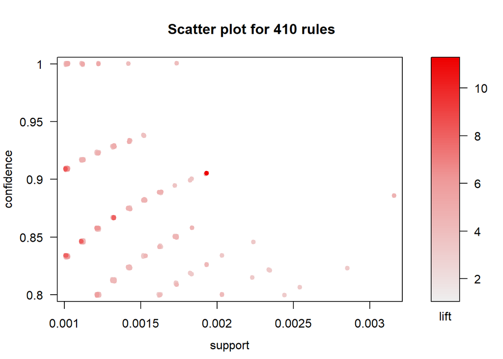

```r
library(arulesViz)
plot(groceryrules)
```

## A two-key plot

Looking at the k-itemset rules by different coding colors.

order 3: 3 itemset rules order 4: 4 itemset rules and so on…

```
## To reduce overplotting, jitter is added! Use jitter = 0 to prevent jitter.
```

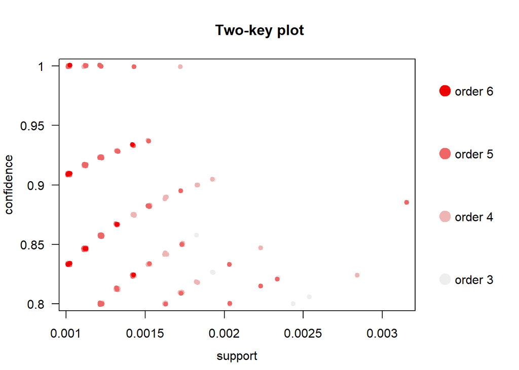

```r
plot(groceryrules, shading="order", control=list(main="Two-key plot"))
```

## Grouped Matrix Plot

The rules are grouped using k-means clustering. Default quality measure is lift. Default plot shows 20 rules for the antecedents (LHS or left hand side).

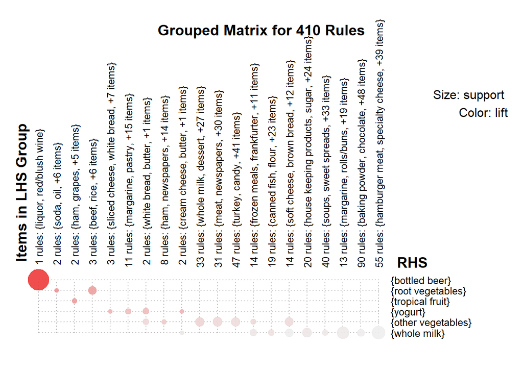

```r
plot(groceryrules, method="grouped")
```

Let’s try 10 rules in LHS

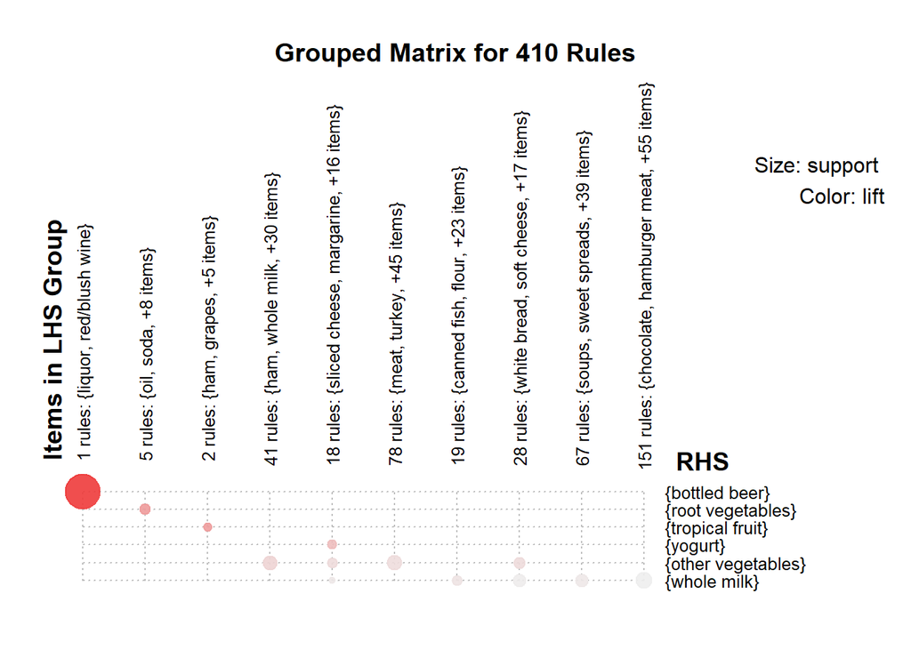

```r
plot(groceryrules, method="grouped", control=list(k=10))
```

## Graph Based Visualizations

This technique only works well for a small number of rules. We will create a graph for the first ten rules. Please note that we are using the sorted grocery rules vector. The default setting will give items and their relationships to each other.

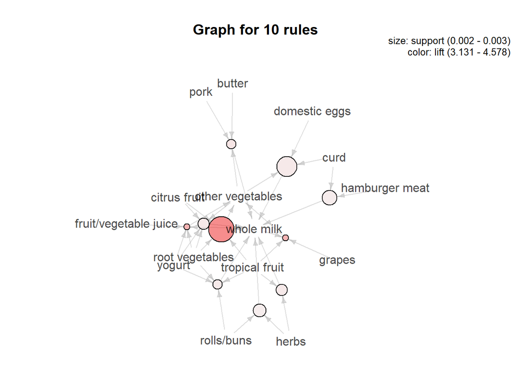

```r
plot(groceryrules_sorted[1:10], method="graph")
```

## Mining Rules Interactively

The features are clunky but still useable. Click “end” to leave interactive mode.

This code chunk won’t run in a markdown file. You will need to do it in an R script.

```r
#plot(groceryrules, engine = 'interactive')
#plot(groceryrules, method="grouped", engine='interactive')
```

# ECLAT Algorithm

Pro: Not as computationally intensive as Apriori

Con: Works best on smaller datasets

Required data format: Vertical

Support of a 1-itemset is the size of its tidset. Support of k-itemset is the intersection of the tidsets of the corresponding itemsets. For example, the support for {beer, diapers} is counted by matching up the tidsets of beer and diapers.

| Beer | Nuts | Diapers | Coffee | Eggs | Milk |
| --- | --- | --- | --- | --- | --- |
| 10 | 10 | 10 | 20 | 30 | 40 |
| 20 | 40 | 20 | 50 | 40 | 50 |
| 30 | 50 | 30 |  | 50 |  |
|  |  | 50 |  |  |  |

We can see that as the size of the transaction database increases, it is more advantageous to count the tidsets than to pass through the databases multiple times like in Apriori.

Method

1. Generate 1-itemset candidate and count support at the same time
2. Prune candidates based on minsup threshold
3. Repeat Steps 1 & 2 until no more candidates can be generated or no frequent itemset is found

## Grocery Shopping in Belgium

We will use a dataset containing 88,162 grocery receipts from an anonymous Belgian supermarket. The receipts contained 16,470 SKUs. The data was collected between 1999 and 2000. More information about this dataset is available from [here](http://www.cs.rpi.edu/~zaki/Workshops/FIMI/data/retail.pdf).

Source of dataset:

Brijs T., Swinnen G., Vanhoof K., and Wets G. (1999), The use of association rules for product assortment decisions: a case study, in: Proceedings of the Fifth International Conference on Knowledge Discovery and Data Mining, San Diego (USA), August 15-18, pp. 254-260. ISBN: 1-58113-143-7.

We will download the dataset into R using a hyperlink. If that does not work, you can import the dataset in as a text file. The text file is posted on Blackboard.

```r
library(Matrix)
library(arules)
#retail <- read.transactions(file="http://fimi.ua.ac.be/data/retail.dat", sep = " ")
retail <- read.transactions(file="C:/Users/PhamX/Dropbox/Fall_2018/BIA_6301/Week_6/retail.txt", sep = " ")
summary(retail)
```

```
## transactions as itemMatrix in sparse format with
##  88162 rows (elements/itemsets/transactions) and
##  16470 columns (items) and a density of 0.0006257289
##
## most frequent items:
##      39      48      38      32      41 (Other)
##   50675   42135   15596   15167   14945  770058
##
## element (itemset/transaction) length distribution:
## sizes
##    1    2    3    4    5    6    7    8    9   10   11   12   13   14   15
## 3016 5516 6919 7210 6814 6163 5746 5143 4660 4086 3751 3285 2866 2620 2310
##   16   17   18   19   20   21   22   23   24   25   26   27   28   29   30
## 2115 1874 1645 1469 1290 1205  981  887  819  684  586  582  472  480  355
##   31   32   33   34   35   36   37   38   39   40   41   42   43   44   45
##  310  303  272  234  194  136  153  123  115  112   76   66   71   60   50
##   46   47   48   49   50   51   52   53   54   55   56   57   58   59   60
##   44   37   37   33   22   24   21   21   10   11   10    9   11    4    9
##   61   62   63   64   65   66   67   68   71   73   74   76
##    7    4    5    2    2    5    3    3    1    1    1    1
##
##    Min. 1st Qu.  Median    Mean 3rd Qu.    Max.
##    1.00    4.00    8.00   10.31   14.00   76.00
##
## includes extended item information - examples:
##   labels
## 1      0
## 2      1
## 3     10
```

Some questions for us to answer:

1. How many items does a typical receipt contain?
2. Which SKUs appear most frequently?
3. What’s the density of the sparse matrix?

```r
freq_retail <- as.data.frame(itemFrequency(retail))
head(freq_retail)
```

```
##       itemFrequency(retail)
## 0              2.007668e-03
## 1              3.017173e-03
## 10             8.076042e-03
## 100            6.125088e-04
## 1000           4.797986e-03
## 10000          2.268551e-05
```

```r
tail(freq_retail)
```

```
##      itemFrequency(retail)
## 9994          1.134276e-04
## 9995          4.537102e-05
## 9996          2.268551e-04
## 9997          1.134276e-05
## 9998          1.134276e-04
## 9999          4.537102e-05
```

Sort the data frame above and find the support for the most popular SKUs.

Default parameter settings for ECLAT: supp = 0.1 and maxlen = 5

What support and maxlen should we use? Many SKUs have support around 0.01. The mean number of items in receipt is 10.

```r
retail.rules<-eclat(retail, parameter=list(supp=0.01, maxlen=10))
```

```
## Eclat
##
## parameter specification:
##  tidLists support minlen maxlen            target   ext
##     FALSE    0.01      1     10 frequent itemsets FALSE
##
## algorithmic control:
##  sparse sort verbose
##       7   -2    TRUE
##
## Absolute minimum support count: 881
##
## create itemset ...
## set transactions ...[16470 item(s), 88162 transaction(s)] done [0.60s].
## sorting and recoding items ... [70 item(s)] done [0.00s].
## creating sparse bit matrix ... [70 row(s), 88162 column(s)] done [0.02s].
## writing  ... [159 set(s)] done [0.03s].
## Creating S4 object  ... done [0.00s].
```

```r
print(retail.rules)
```

```
## set of 159 itemsets
```

159 rules found! Let’s dig in deeper. We can use inspect() to view all the rules.

```r
inspect(retail.rules)
```

```
##       items          support    count
## [1]   {37,38}        0.01186452  1046
## [2]   {286,38}       0.01265852  1116
## [3]   {12925,39}     0.01063950   938
## [4]   {1146,39}      0.01114993   983
## [5]   {39,79}        0.01260180  1111
## [6]   {48,79}        0.01012908   893
## [7]   {1327,39}      0.01311223  1156
## [8]   {1327,48}      0.01097979   968
## [9]   {39,438}       0.01429187  1260
## [10]  {438,48}       0.01162632  1025
## [11]  {39,60}        0.01114993   983
## [12]  {255,39}       0.01198929  1057
## [13]  {255,48}       0.01198929  1057
## [14]  {39,533}       0.01045802   922
```

[output cut: 145 more lines]

Alternatively, we can use ruleInduction() and set the confidence level to filter the rules. The default confidence=0.8

```r
retail.rules.review<-ruleInduction(retail.rules,retail)
retail.rules.sorted<-sort(retail.rules.review, by = c("lift", "confidence"))
inspect(retail.rules.sorted)
```

```
##      lhs            rhs  support    confidence lift     itemset
## [1]  {110,39,48} => {38} 0.01169438 0.9942141  5.620153 19
## [2]  {170,39,48} => {38} 0.01353191 0.9892206  5.591925 42
## [3]  {110,39}    => {38} 0.01973639 0.9891984  5.591800 20
## [4]  {170,48}    => {38} 0.01744516 0.9877970  5.583878 44
## [5]  {110,48}    => {38} 0.01543749 0.9862319  5.575030 21
## [6]  {170,39}    => {38} 0.02290102 0.9805731  5.543042 43
## [7]  {170}       => {38} 0.03437989 0.9780574  5.528821 48
## [8]  {110}       => {38} 0.03090901 0.9753042  5.513258 25
## [9]  {37}        => {38} 0.01186452 0.9739292  5.505485  1
## [10] {36,39,48}  => {38} 0.01225018 0.9677419  5.470509 32
## [11] {36,48}     => {38} 0.01542615 0.9604520  5.429300 34
## [12] {36,39}     => {38} 0.02206166 0.9548355  5.397551 33
## [13] {36}        => {38} 0.03164629 0.9502725  5.371757 38
## [14] {286}       => {38} 0.01265852 0.9433643  5.332706  2
## [15] {38,41,48}  => {39} 0.02258343 0.8386689  1.459077 71
## [16] {41,48}     => {39} 0.08355074 0.8168108  1.421049 86
## [17] {225,48}    => {39} 0.01587986 0.8064516  1.403027 58
```

# Not just for shopping carts

http://www.rdatamining.com/examples/association-rules